# Codebraid with Jupyter kernels

Using Codebraid with Jupyter kernels rather than the built-in code execution system is as simple as adding a Codebraid setting to the document YAML metadata. For example, this document begins with the following metadata:

```
---
title: "Codebraid with Jupyter kernels"
codebraid:
  jupyter: true
---
```

In this case, Codebraid automatically selects a kernel based on code language. It is also possible to select a specific kernel. For example,

```
---
codebraid:
  jupyter:
    kernel: python3
---
```

This would set a default kernel for the entire document. The kernel can be overridden for an individual session by setting `jupyter_kernel=<kernel>` on the first code chunk of a session.

## [Matplotlib](https://matplotlib.org/)

Plots are included automatically.

````
```{.python .cb-nb}
%matplotlib inline
import matplotlib.pyplot as plt
import numpy as np
x = np.linspace(0, 2*np.pi, 1001)
x_tick_values = np.linspace(0, 2*np.pi, 5)
x_tick_labels = ['0', r'$\pi/2$', r'$\pi$', r'$3\pi/2$', r'$2\pi$']
plt.plot(x, np.cos(x), label=r'$\cos(x)$')
plt.plot(x, np.sin(x), label=r'$\sin(x)$')
plt.xticks(x_tick_values, x_tick_labels)
plt.legend(prop={'size': 12})
plt.grid()
```
````

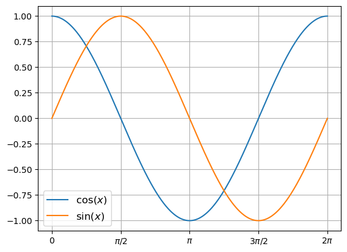

```python
%matplotlib inline
import matplotlib.pyplot as plt
import numpy as np
x = np.linspace(0, 2*np.pi, 1001)
x_tick_values = np.linspace(0, 2*np.pi, 5)
x_tick_labels = ['0', r'$\pi/2$', r'$\pi$', r'$3\pi/2$', r'$2\pi$']
plt.plot(x, np.cos(x), label=r'$\cos(x)$')
plt.plot(x, np.sin(x), label=r'$\sin(x)$')
plt.xticks(x_tick_values, x_tick_labels)
plt.legend(prop={'size': 12})
plt.grid()
```

If there are errors or warnings, they are shown as well. Copying this code into a Jupyter notebook yields the same output.

````
```{.python .cb-nb}
plt.plot(x, np.sin(x)/x, label=r'$\sin(x)/x$')
plt.plot(x, np.cos(np.sin(x)), label=r'$\cos(\sin(x))$')
plt.xticks(x_tick_values, x_tick_labels)
plt.legend(prop={'size': 12})
plt.grid()
```
````

```python
plt.plot(x, np.sin(x)/x, label=r'$\sin(x)/x$')
plt.plot(x, np.cos(np.sin(x)), label=r'$\cos(\sin(x))$')
plt.xticks(x_tick_values, x_tick_labels)
plt.legend(prop={'size': 12})
plt.grid()
```

```
~\AppData\Local\Temp\ipykernel_15472\293500280.py:1: RuntimeWarning: invalid value encountered in divide
  plt.plot(x, np.sin(x)/x, label=r'$\sin(x)/x$')
```

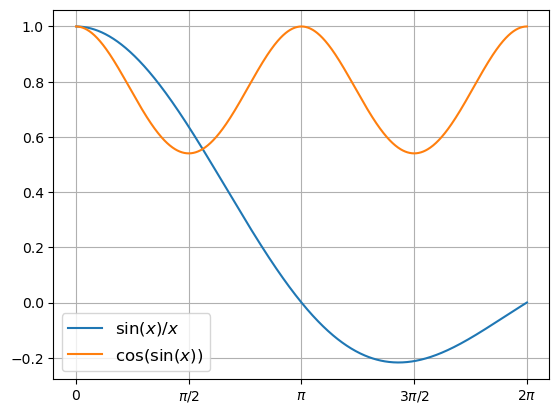

## [SymPy](https://www.sympy.org/)

SymPy equations are displayed as well. This example runs in a separate session from the plots above. Multiple Jupyter kernels can be used within a single document, and multiple independent sessions are possible per kernel.

````
```{.python .cb-nb session=sympy name=sympy1}
from sympy import *
init_printing(use_latex='mathjax')
x = Symbol('x')
eqn = E**(-x**2)
int_eqn = Integral(eqn, (x, -oo, oo))
int_eqn
```
````

```python
from sympy import *
init_printing(use_latex='mathjax')
x = Symbol('x')
eqn = E**(-x**2)
int_eqn = Integral(eqn, (x, -oo, oo))
int_eqn
```

$\displaystyle \int\limits_{-\infty}^{\infty} e^{- x^{2}}\, dx$

````
```{.python .cb-nb session=sympy name=sympy2}
int_eqn.doit()
```
````

```python
int_eqn.doit()
```

$\displaystyle \sqrt{\pi}$

A Jupyter kernel can provide multiple formats for representing an object. SymPy typically provides a LaTeX representation, a plain-text representation, and a PNG representation. By default, Codebraid chooses display formats in this order of precedence: LaTeX, Markdown, PNG, JPG, plain. (This can be customized; see `rich_output` in the documentation for details.) So Codebraid displays the SymPy math in LaTeX form. For this to render as nicely as possible in the browser, Pandoc should be run with one of the flags for rendering math in HTML, such as `--mathjax`. For this document, Pandoc was used with `--webtex` to convert LaTeX into PNG during the document build process.

`cb-paste` works with rich output like plots and LaTeX, just like it normally does with code, stdout, and stderr.

````
```{.cb-paste copy=sympy1+sympy2 show=rich_output}
```
````

$\displaystyle \int\limits_{-\infty}^{\infty} e^{- x^{2}}\, dx$

$\displaystyle \sqrt{\pi}$

## Customizing output

When working with `rich_output` formats that have a `text/*` mime type, such as LaTeX and Markdown, it is possible to display the rendered output or show the markup. For example, using `show=rich_output:latex:raw` displays the raw (rendered) LaTeX, while `show=rich_output:latex:verbatim` displays the LaTeX markup verbatim.

````
```{.cb-paste copy=sympy1 show=rich_output:latex:raw}
```
````

$\displaystyle \int\limits_{-\infty}^{\infty} e^{- x^{2}}\, dx$

````
```{.cb-paste copy=sympy1 show=rich_output:latex:verbatim}
```
````

```latex
$\displaystyle \int\limits_{-\infty}^{\infty} e^{- x^{2}}\, dx$
```